# Part II - Prosper Loan Exploratory Analysis

## Dataset Overview

> The dataset contains 113,937 loan observations and 81 variables such as Listing category, Borrower's state, Interest Rate, Income Range, Listing Date, Investors, etc. From those 81 variables, I extracted 19 variables to work with to provide insight on my area of interest.

## Number of Borrowers in each State

> The dataset is based in the United States. It is important to which states individuals take loans the most.

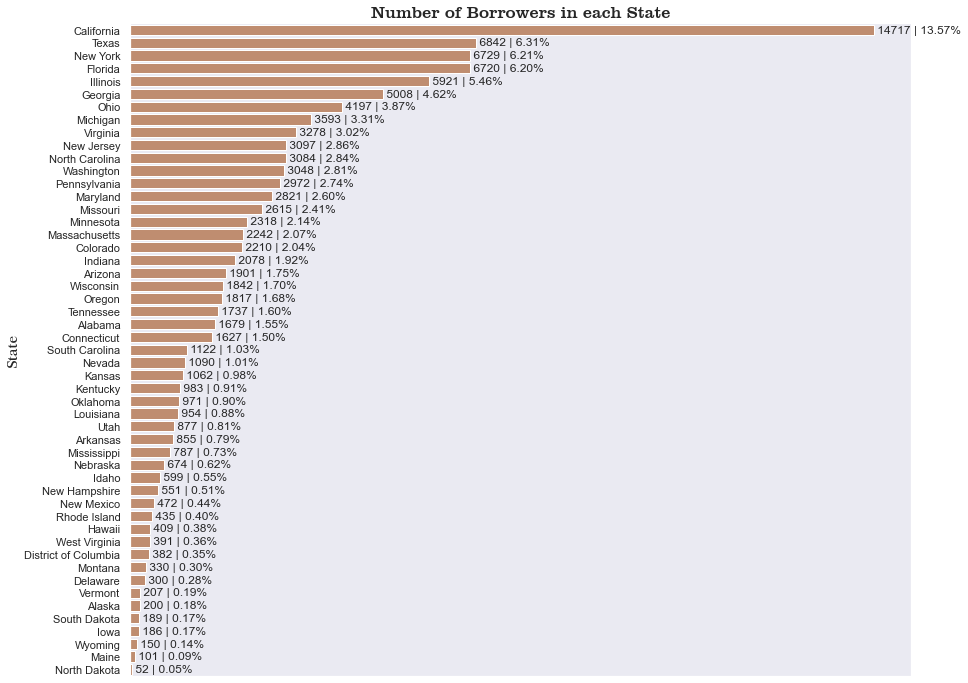

The state with the most number of borrowers by a large margin is California which had more than 13% of the loans taken. The next state is Texas which had 6.3% of the total borrowers. After that, we have New York and Florida

## Number of Individuals that take loans in each income range

[figure not shown]

Most loans were taken by individuals within the \$25,000-49,99 and \\$50,000-74,999 income range. This implies that most individuals that take loans are from mid-range income class. Income class below \$24,999 generally have lower numbers of individuals with loans. This could mean that individuals in lower income class are not given loans or don't take loans.

## Distribution of Monthly Loan Payment and Borrower's Rate

> A distribution can easily be seen using a Histogram. I plotted a histogram to see the distribution of monthly loan payment and borrower's interest rate

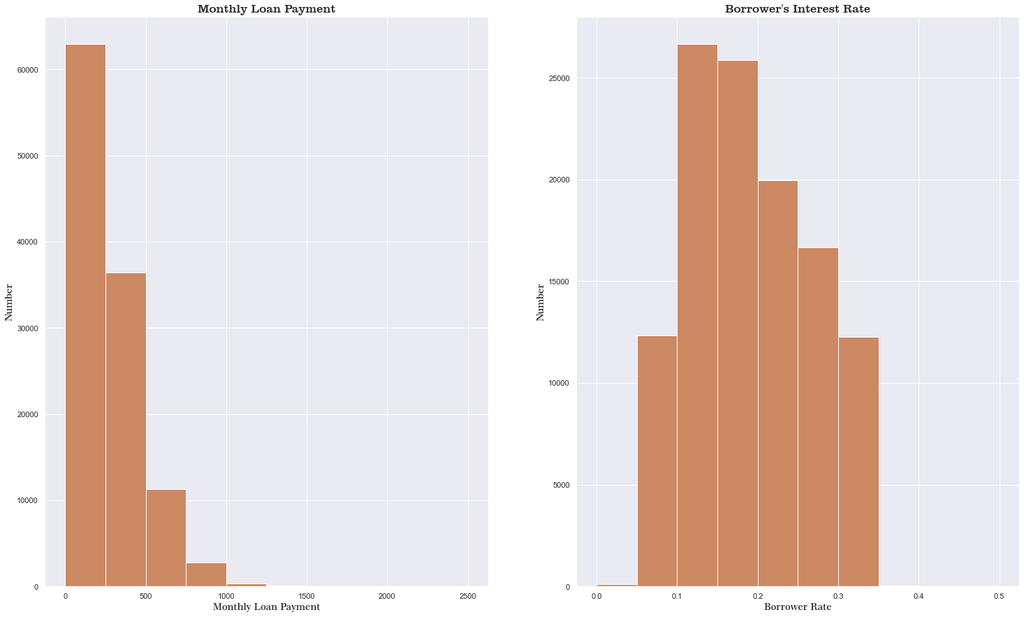

A majority of monthly loan payment is between \$0 and \\$250. The other individuals pay between \$250 and \\$1000 with just a few paying above that. Typically the borrower's interest ranges between 0.1 and 0.35. It peaks between 0.1 and 0.15.

## Relationship between Income Range, Employment Status and Borrower's Interest Rate

> It is expected that people with higher income range would have access to less interest rate and those employed would also have less interesst rate.

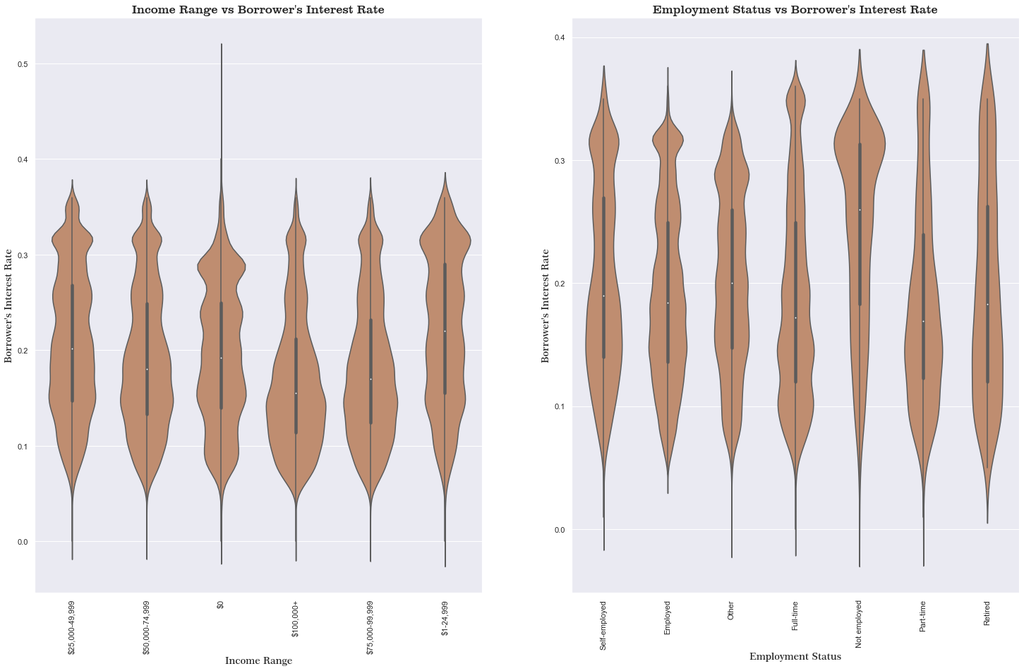

On the violin plot of the income range and borrower's interest rate, the higher the income range, the lower the borrower's interest rate and the range with the highest borrower's interest rate is the \$1-24,999 range. Interest rate seems to be the highest in the not employed status although there less interest rate in the part-time and retired group than in the other groups. Further investigation would be done in the multivariate exploration section

## Interest rate yearly progression for home owners and non-home owners

> Could there be any form of difference between those that have homes and those that dont?

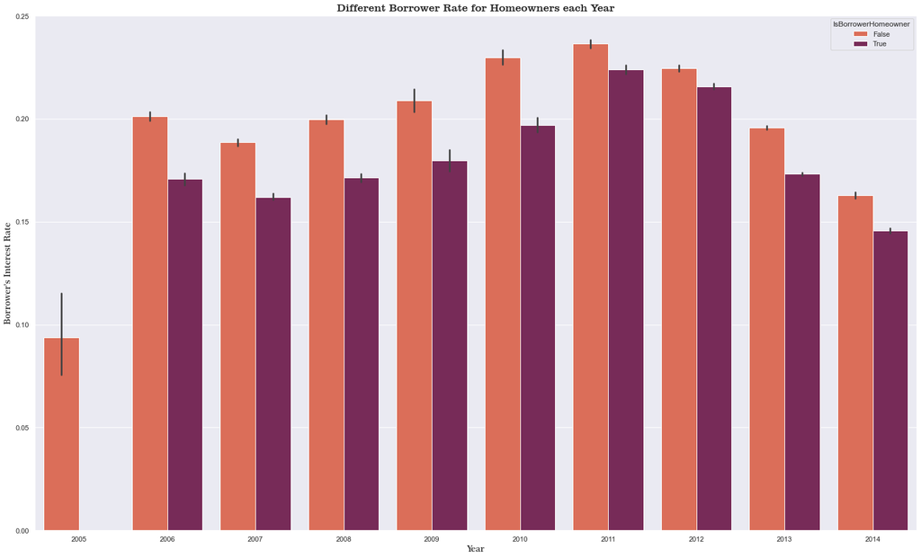

## Relationship between Income Range, Employment Status, Interest Rate and Loan Term

> It would be safe to think that shorter term and higher income range would reduce the interest rate of the borrower. This may not necessarily be so.

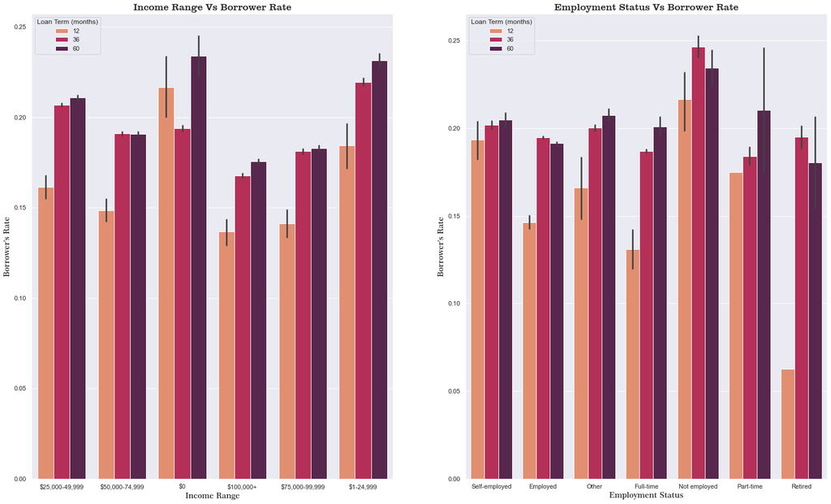

There's a general trend of Borrower's Interest rate going up with lowering income range and increasing loan term. The highest Interest rate belong to those in the \$0 income range and 60 months or 5 year loan period. The lowest interest rate belong to those earning more than \\$100,000 with a 12 month or 1 year loan period. In terms of employment status, those that are retired and are taking a 12 month or 1 year loan have the least interest while those that are not employed have the highest interest rate with those taking a 36 month or 3 year loan having the highest interest rate. Individuals that are Employed and full time generally had less interest rate.

## Relationship between Employment Status, Prosper Rating, Income Range, and Interest Rate

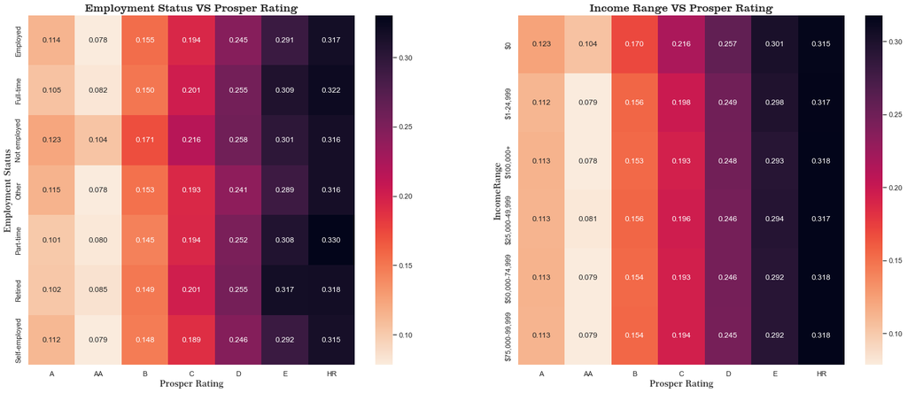